# landUseESDA

## **Food Security in Vietnam (2012–2021): A Geospatial Primer**

### Exploratory Spatial Data Analysis (ESDA) of Land Use and Demographic Variables

*(Part of a broader study on Vietnam’s development and food security)*

This project applies *Exploratory Spatial Data Analysis (ESDA)* to explore spatial patterns and dependencies in Vietnam's land use, demographic, and socioeconomic data from 2012 to 2021. Using *spatial autocorrelation* techniques like *Moran’s I* and *Local Indicators of Spatial Association (LISA)*, the analysis identifies spatial clusters, outliers, and correlations between land use types (agriculture, forestry, homestead) and key demographic factors (population, income). The findings are visualized using choropleth maps to highlight geographic trends and insights related to food security.

### key Components

- Data Preparation  
  Cleaned and preprocessed spatial data from multiple sources to ensure consistency and readiness for analysis.
- Spatial Data Analysis  
  Conducted global and local spatial autocorrelation to uncover spatial dependencies in land use and demographic variables using GeoPandas and PySAL.
- Statistical Methods  
  Applied Moran’s I and Local Indicators of Spatial Association (LISA) to detect clustering, dispersion, and outliers.
- Geospatial Visualization  
  Created choropleth maps and custom visualizations using Matplotlib and Folium to illustrate spatial trends and regional patterns clearly.
- Interpretation of Spatial Patterns  
  Identified and interpreted spatial clusters, geographic outliers, and relationships between land use types and demographic indicators.

### Technologies Used:

- Python, GeoPandas, PySAL, Matplotlib, Folium, Pandas

# 🗂️ Dataset Overview

**All area units** are in **thousands of hectares** (1 ha = 10,000 m²)  
**Income** values are in **thousand VND**, adjusted for inflation to 2020 using VHLSS5

| Column | Description |
| --- | --- |
| `Province` | Province name |
| `AdminUnit` | Administrative unit name |
| `TotalArea*` | Total land area of the unit |
| `Agri*` | Agricultural land |
| `Fores*` | Forestry land |
| `Spec*` | Special-use land |
| `Hmstd*` | Homestead/residential land |
| `incm*` | Income (in thousand VND), adjusted to 2020 |
| `TotAvgPop_*` | Total average population (2012, 2016, 2020) |
| `UrbanPop_*` | Urban population (2012, 2016, 2020) |
| `RuralPop_*` | Rural population (2012, 2016, 2020) |
| `Entpr_*` | Number of enterprises (by year) |
| `Emply_*` | Enterprise employment (by year) |

**Groupings of Admin Units by Vietnam Yearbook**

[figure not shown]

# 📦 Imports and Config

This section loads the spatial dataset in KML format — a district-level boundary map of Vietnam enriched with temporal land use and demographic attributes. Initial previews validate structure and content before analysis begins.

```python
import geopandas as gpd
import matplotlib.pyplot as plt

# Suppress warnings for cleaner output
import warnings
warnings.filterwarnings("ignore")

import fiona
# enable KML support which is disabled by default
fiona.drvsupport.supported_drivers['libkml'] = 'rw'
fiona.drvsupport.supported_drivers['LIBKML'] = 'rw'
```

**🌐 Load enriched Land Use KML**

Imports the polygon-based KML file containing land use and population statistics across administrative units (2012, 2016, 2021).

Dataset includes 48 variables across 63 units, with geometry attributes retained for geospatial analysis.

```python
kmlfile = gpd.read_file("geofiles/landuseTmprlESDA.kml")
kmlfile.shape
```

```
(63, 48)
```

**🔍 Quick Preview**

Previews the structure of the loaded GeoDataFrame and confirms successful import of all relevant fields.

Includes total land area, multiple land use types, population distributions, enterprise and employment data.

```python
# sanity check
kmlfile.head(3)
```

|  | Name | description | timestamp | begin | end | altitudeMode | tessellate | extrude | visibility | drawOrder | ... | RuralPop_16 | RuralPop_12 | Province | Entpr_2012 | Entpr_2016 | Entpr_2020 | Emply_2020 | Emply_2016 | Emply_2012 | geometry |
| --- | --- | --- | --- | --- | --- | --- | --- | --- | --- | --- | --- | --- | --- | --- | --- | --- | --- | --- | --- | --- | --- |
| 0 | An Giang | NaN | NaT | NaT | NaT | clampToGround | -1 | 0 | -1 | NaN | ... | 1495.8 | 1507.8 | Mekong River Delta | 2297 | 3023 | 4794 | 68456 | 62057 | 55998 | POLYGON Z ((105.11524 10.95566 0.00000, 105.11... |
| 1 | Ba Ria - Vung Tau | NaN | NaT | NaT | NaT | clampToGround | -1 | 0 | -1 | NaN | ... | 529.5 | 521.1 | South East | 5456 | 7575 | 10946 | 201337 | 195527 | 166318 | MULTIPOLYGON Z (((106.08110 8.57754 0.00000, 1... |
| 2 | Bac Giang | NaN | NaT | NaT | NaT | clampToGround | -1 | 0 | -1 | NaN | ... | 1468.8 | 1433.4 | Northern midlands and mountain areas | 1705 | 2576 | 6549 | 302376 | 174718 | 111374 | POLYGON Z ((106.16542 21.62022 0.00000, 106.16... |

3 rows × 48 columns

```python
# list columns
kmlfile.columns
```

```
Index(['Name', 'description', 'timestamp', 'begin', 'end', 'altitudeMode',
       'tessellate', 'extrude', 'visibility', 'drawOrder', 'icon', 'Code',
       'TotalArea21', 'TotalArea16', 'TotalArea12', 'TotalPctChg', 'Agri21',
       'Agri16', 'Agri12', 'Fores21', 'Fores16', 'Fores12', 'Spec21', 'Spec16',
       'Spec12', 'Hmstd21', 'Hmstd16', 'Hmstd12', 'incmInfl_2012',
       'incmInfl_2016', 'incm_2020', 'TotAvgPop_20', 'TotAvgPop_16',
       'TotAvgPop_12', 'UrbanPop_20', 'UrbanPop_16', 'UrbanPop_12',
       'RuralPop_20', 'RuralPop_16', 'RuralPop_12', 'Province', 'Entpr_2012',
       'Entpr_2016', 'Entpr_2020', 'Emply_2020', 'Emply_2016', 'Emply_2012',
       'geometry'],
      dtype='object')
```

**🗺️ Get Ready for Plotting**

A reusable function is created to generate choropleth maps for land use over time. This supports consistent visualization of temporal change across different dimensions (e.g., total area, agriculture, forestry).

```python
from mpl_toolkits.axes_grid1 import make_axes_locatable
from matplotlib.colorbar import ColorbarBase
from matplotlib.colors import Normalize
from matplotlib.cm import ScalarMappable
```

```python
# plot map and color according to column in kml
def plot1by3(col_set = ['TotalArea21','TotalArea16','TotalArea12']
            , colorscheme = 'YlOrBr'):

    """
    Creates a set of three choropleth maps displaying land area data (for the years 2012, 2016, 2021).
    Each map is colored according to the respective column in col_set.

    Parameters:
    col_set : list
        List of column names to plot (e.g., land area for different years).
    colorscheme : str
        Color map scheme to use for visualization.
    """

    # figure and axes
    fig, (ax0,ax1,ax2) = plt.subplots(1,3,figsize=(9, 6))

    # Set the background color
    fig.set_facecolor('gainsboro')

    ax_set = [ax0, ax1, ax2]

    # Find the overall minimum and maximum values for color normalization
    overall_min = min(kmlfile[col].min() for col in col_set)
    overall_max = max(kmlfile[col].max() for col in col_set)

    # Loop through each axis and target column to create individual maps
    for ax,tgtcol in zip(ax_set, col_set):

        # Plot df colors based on 'TotalArea'
        sm = kmlfile.plot(ax=ax
                , column=tgtcol
                , cmap=colorscheme
                , edgecolor='black'
                , legend=False)

        # Sort by 'TotalArea'
        kmlfile_sorted = kmlfile.sort_values(by=tgtcol)

        # Extract names of the two largest and two smallest provinces
        largest_provinces = kmlfile_sorted['Name'].tail(2).tolist()
        smallest_provinces = kmlfile_sorted['Name'].head(2).tolist()

        # Add plotting customizations
        titlestring = tgtcol + ' Use\nLargest 2:' \
                + largest_provinces[0] + ', ' + largest_provinces[1] + '\n'\
                + ' Smallest 2:' + smallest_provinces[0] + ', ' + smallest_provinces[1]
        ax.set_title(titlestring, fontsize=10)
        ax.set_xticks([])
        ax.set_yticks([])
        ax.set_facecolor('#81a0af')
        ax.set_xlim((101.5,110))
        ax.set_ylim((8.2,23.5))

    # Add colorbar with shrink factor using ScalarMappable
    divider = make_axes_locatable(ax0)
    cax = divider.append_axes("left", size="5%",pad=0.1)
    sm = ScalarMappable(cmap=colorscheme
                            , norm=Normalize(vmin=overall_min
                                            , vmax=overall_max))

    sm._A = []  # fake up the array of the scalar mappable
    cbar = fig.colorbar(sm, cax=cax)
    cbar.ax.yaxis.set_ticks_position('left')

    # prevent overlap
    fig.tight_layout()
    plt.show()
```

## 📊 AU Area: Temporal Change (2012–2021)

Objective: Visualize how total administrative unit area changes over time (2012, 2016, 2021). Note: Boundary redraws may occur without affecting overall land area of the country.

- Serves as a starting point to explore whether larger AUs tend to have a higher share of agricultural land.
- Highlights the 2 largest and 2 smallest administrative units by land area in each year.
- Encourages readers to observe stability vs. variation over time using color intensity.

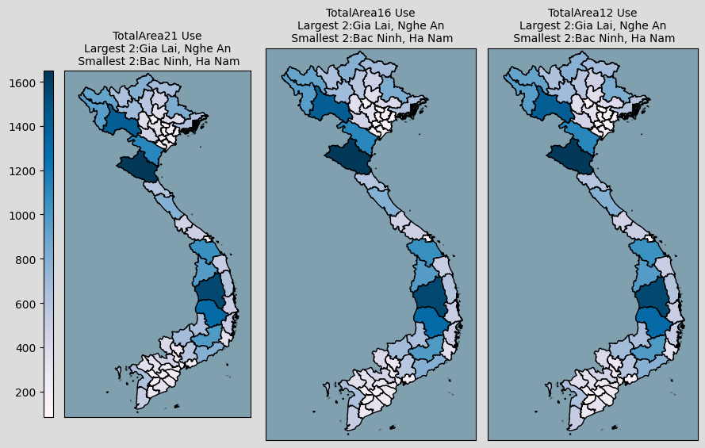

```python
plot1by3(colorscheme='PuBu')
```

## 📈 Percentage Change in Area (2012–2021)

Objective: Show percentage change in total land area by administrative unit between 2012 and 2021. This helps identify regions with significant changes (e.g., due to redistricting or boundary adjustments).

- Labels top 2 and bottom 2 provinces by area change.
- Color scale emphasizes magnitude of percentage shifts.

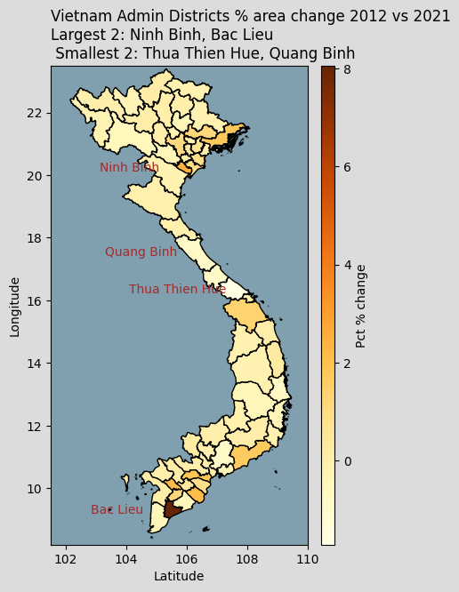

```python
def areaPlot(tgtcol = 'TotalPctChg', colorscheme = 'YlOrBr'):

    """
    Creates a choropleth map displaying the percentage change in total area (2012 vs. 2021) across provinces.
    The color intensity reflects the magnitude of the change, with labels for the largest and smallest changes.

    Parameters:
    tgtcol : str
        The column name representing the percentage change (e.g., 'TotalPctChg').
    colorscheme : str
        Color map scheme to use for visualization.
    """

    # Create figure and axis
    fig, ax = plt.subplots(figsize=(6, 7))

    # Set the background color
    fig.set_facecolor('gainsboro')

    kmlfile.plot(ax=ax
                 , column=tgtcol
                 , cmap=colorscheme
                 , edgecolor='black'
                 , legend=False)

    # Sort by 'TotalArea'
    kmlfile_sorted = kmlfile.sort_values(by=tgtcol)

    # Extract names of the two largest and two smallest provinces
    largest_provinces = kmlfile_sorted['Name'].tail(2).tolist()
    smallest_provinces = kmlfile_sorted['Name'].head(2).tolist()


    # Add labels for the two largest and two smallest provinces
    for index, row in kmlfile.iterrows():
        if row['Name'] in largest_provinces + smallest_provinces:
            ax.text(row.geometry.centroid.x-1.8 #offset
                    , row.geometry.centroid.y
                    , row['Name']
                    , fontsize=10
                    , color='brown'
                    , ha='center'
                    , va='center')

    # Add plotting customizations
    titlestring = 'Vietnam Admin Districts % area change 2012 vs 2021\nLargest 2: ' \
        + largest_provinces[0] + ', ' + largest_provinces[1] + '\n'\
                + ' Smallest 2: ' + smallest_provinces[0] + ', ' + smallest_provinces[1]
    ax.set_title(titlestring, fontsize=12, loc='left')
    ax.set_xlabel('Latitude', fontsize=10)
    ax.set_ylabel('Longitude', fontsize=10)
    ax.set_facecolor('#81a0af')
    ax.set_xlim((101.5,110))
    ax.set_ylim((8.2,23.5))

    # Add colorbar with shrink factor using ScalarMappable
    divider = make_axes_locatable(ax)
    cax = divider.append_axes("right", size="5%", pad=0.1)
    sm = ScalarMappable(cmap=colorscheme
                        , norm=Normalize(vmin=kmlfile[tgtcol].min()
                                         , vmax=kmlfile[tgtcol].max()))

    sm._A = []  # fake up the array of the scalar mappable
    cbar = fig.colorbar(sm, cax=cax, label='Pct % change')

    # Show the plot
    plt.show()

areaPlot()
```

**Percentage change in AU land area from 2012 vs 2021**

[figure not shown]

# 🧭 Land Use Shifts Across Time (2012–2021)

Before applying spatial autocorrelation techniques like Moran’s I and LISA, this section builds an intuitive baseline of where and how land use is shifting across Vietnam. Each land type is visualized through a set of temporal choropleths (2012, 2016, 2021), highlighting both national trends and local variations.

Internal reallocations on agricultural, forestry, homestead, and special-use land across administrative units may reflect economic development, urban pressure, or environmental stressors like saltwater intrusion.

These choropleths help surface early signals — spatial clustering, regional contrasts — that later analysis will quantify more formally.

## 🌾 Agricultural Land Use: Temporal Change (2012–2021)

Objective: Visualize how agricultural land area evolved across administrative units over time.

- Highlights the 2 largest and 2 smallest agricultural areas in each year.
- Areas in the **north show growth**, while parts of the **south show decline**.
- Provides a basis to investigate whether changes are linked to urbanization, inland migration, or environmental impacts like saltwater intrusion.

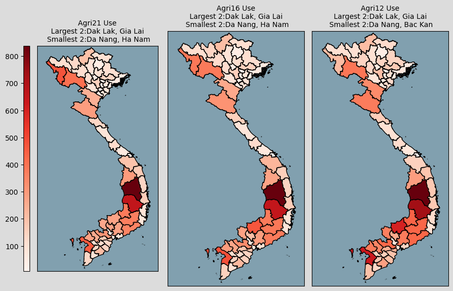

```python
plot1by3(col_set=['Agri21' ,'Agri16' ,'Agri12']
            , colorscheme='Reds')
```

This view indicates agriculture land area is growing in northern provinces but shrinking in the south. It provides the basis to investigate if urbanizationn, inland migration or saltwater intrusion(especially delta areas) has occured in southern provinces, reducing agriculture activites.

**Aggregated to Provincial level**  
*2012 to 2021 change*

- 7% Northern midlands and mountain areas
- -1% Red river Delta
- 3% North central area and central coastal area
- 10% Central highlands(*biggest growth AU are Dak Lak and Gia Lai*)
- -3% South East
- -1% Mekong river delta

> *note*: Provinces are listed from north to south (by descending latitude).  
> For regional groupings (e.g., Mekong Delta, Central Highlands), see `Dataset Overview`.

***% Agriculture land in province(agriculture land area in province/total province land area)***

[figure not shown]

*done in Excel to keep it crisp here*

**plot temporal change in forestry use 2021-2016-2012**  
identify 2 Admin Units with largest(darkest color hue) and smallest(lightest color hue) change

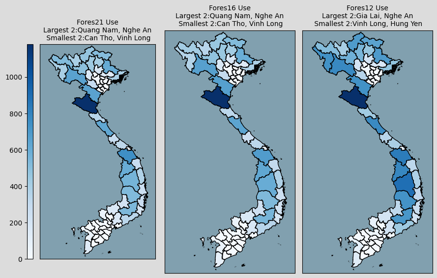

```python
plot1by3(col_set=['Fores21' ,'Fores16' ,'Fores12']
            , colorscheme='Blues')
```

**Forestry use aggregated by province, 2021-2016-2012** change from 2012 to 2021

- -7% Northern midlands and mountain areas
- 0% Red river Delta
- 4% North central area and central coastal area
- 0% Central highlands
- -1% South East
- -1% Mekong river delta

> *note*: Provinces are listed from north to south (by descending latitude).  
> For regional groupings, see `Dataset Overview`.

[figure not shown]

**plot temporal change in homestead use 2021-2016-2012**  
identify 2 Admin Units with largest(darkest color hue) and smallest(lightest color hue) change

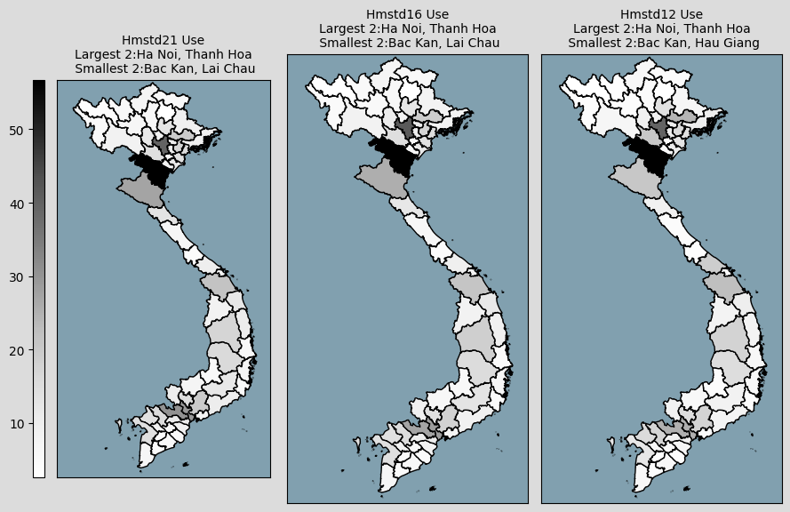

```python
plot1by3(col_set=['Hmstd21' ,'Hmstd16' ,'Hmstd12']
            , colorscheme='Greys')
```

It is evident AU choropleths shows a different view from aggreation at provincial level.

- AUs with largest homestead use in the northern provinces
  - Ha Noi is in the Red River Delta
  - Thanh Hoa is in North central area and central coastal area
- Only 1 province(Mekong river delta) showed increased homestead use

**Homestead use aggregated by province, 2021-2016-2012** change from 2012 to 2021

- 0% Northern midlands and mountain areas
- 0% Red river Delta
- 0% North central area and central coastal area
- 0% Central highlands
- 0% South East
- 1% Mekong river delta

> *note*: Provinces are listed from north to south (by descending latitude).  
> For regional groupings, see `Dataset Overview`.

[figure not shown]

**plot temporal change in special use 2021-2016-2012**  
identify 2 Admin Units with largest(darkest color hue) and smallest(lightest color hue) change  
*special*: reserved for government use, like military bases

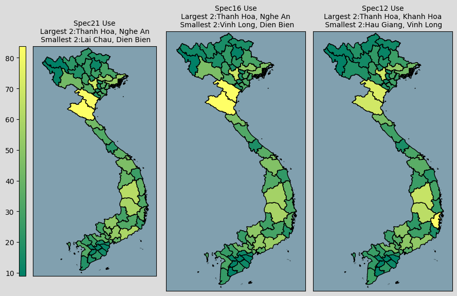

```python
plot1by3(col_set=['Spec21' ,'Spec16' ,'Spec12']
            , colorscheme='summer')
```

**Special use aggregated by province, 2021-2016-2012** change from 2012 to 2021

- 0% Northern midlands and mountain areas
- 0% Red river Delta
- 0% North central area and central coastal area
- 1% Central highlands
- 1% South East
- 0% Mekong river delta

> *note*: Provinces are listed from north to south (by descending latitude).  
> For regional groupings, see `Dataset Overview`.

[figure not shown]

# 🧭 Spatial Autocorrelation of Agricultural Land Use (2021)

After building a visual understanding of land use changes, this section takes things a step further by asking: *Are these changes spatially connected?* Using spatial autocorrelation techniques like **Moran’s I** and **LISA**, we explore whether provinces with similar agricultural land use tend to cluster — or stand apart.

We’ll begin with a global perspective to spot broad clustering patterns, then zoom into local regions to identify hotspots, coldspots, and outliers. Finally, we bring in other layers — income, population, enterprise, employment — to see how agricultural land use fits into the wider socioeconomic picture.

```python
from esda.moran import Moran
from libpysal.weights import Queen
import libpysal
from splot.esda import moran_scatterplot
```

```python
# get col names
kmlfile.columns
```

```
Index(['Name', 'description', 'timestamp', 'begin', 'end', 'altitudeMode',
       'tessellate', 'extrude', 'visibility', 'drawOrder', 'icon', 'Code',
       'TotalArea21', 'TotalArea16', 'TotalArea12', 'TotalPctChg', 'Agri21',
       'Agri16', 'Agri12', 'Fores21', 'Fores16', 'Fores12', 'Spec21', 'Spec16',
       'Spec12', 'Hmstd21', 'Hmstd16', 'Hmstd12', 'incmInfl_2012',
       'incmInfl_2016', 'incm_2020', 'TotAvgPop_20', 'TotAvgPop_16',
       'TotAvgPop_12', 'UrbanPop_20', 'UrbanPop_16', 'UrbanPop_12',
       'RuralPop_20', 'RuralPop_16', 'RuralPop_12', 'Province', 'Entpr_2012',
       'Entpr_2016', 'Entpr_2020', 'Emply_2020', 'Emply_2016', 'Emply_2012',
       'geometry'],
      dtype='object')
```

## 📈 Global Moran’s I

**Objective:** Measure overall spatial clustering in agricultural land use.

Global Moran’s I tells us whether agricultural land use is clustered in certain areas or spread out across the country. Essentially, it gives us a sense of how deeply entrenched agriculture is within the country’s landscape — if regions with similar agricultural land use are grouped together, we can infer that agriculture is more concentrated, rather than dispersed across urbanized or industrialized regions.

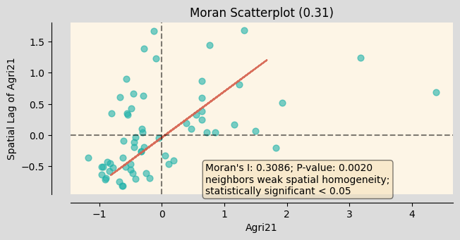

```
Moran's I: 0.3086386678889503
P-value: 0.002
```

```python
# Calculate spatial weights matrix
wmatrix = Queen.from_dataframe(kmlfile, geom_col='geometry', ids='Name')

# Calculate Moran's I statistic
moran = Moran(kmlfile.Agri21, wmatrix)

# Plot Moran's Scatterplot
fig, ax = moran_scatterplot(moran, aspect_equal=True)
fig.set_facecolor('gainsboro')
ax.set_facecolor('oldlace')

points = ax.collections[0]
points.set_color('lightseagreen')

plt.ylabel('Spatial Lag of Agri21')
plt.xlabel('Agri21')

ax.annotate(f"Moran's I: {moran.I:.4f}; P-value: {moran.p_sim:.4f}\n" \
            + "neighbors weak spatial homogeneity;\nstatistically significant < 0.05"
            , xy=(0.7, -0.45)
            , ha='left', va='top', fontsize=10
            , bbox=dict(boxstyle='round', facecolor='wheat', alpha=0.5))

plt.show()

# Print Moran's I statistic and p-value
print(f"Moran's I: {moran.I}")
print(f"P-value: {moran.p_sim}")
```

- Global Moran's I at 0.3086, indicates moderate positive spatial autocorrelation — nearby AUs tend to have similar levels of agricultural land use.
- Queen contiguity matrix used accounts for all neighboring directions

Let's try using `plot_moran` that visualizes the distribution

```python
from splot.esda import plot_moran
```

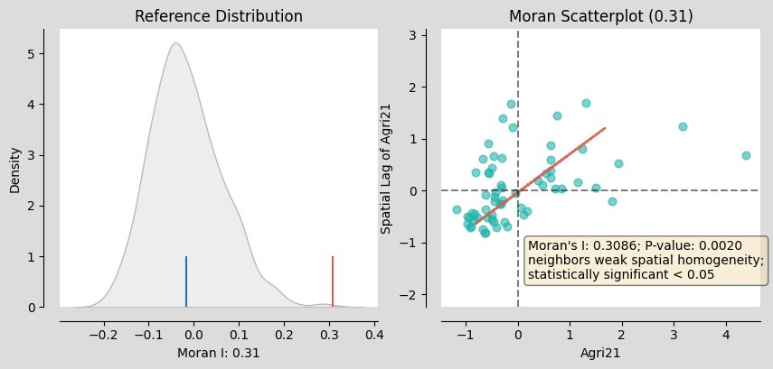

```python
fig, axs = plot_moran(moran, zstandard=True, figsize=(10,4),
                      scatter_kwds={'color': 'lightseagreen', 'alpha': 0.6})

fig.set_facecolor('gainsboro')

axs[1].set_xlabel('Agri21')
axs[1].set_ylabel('Spatial Lag of Agri21')

axs[1].annotate(f"Moran's I: {moran.I:.4f}; P-value: {moran.p_sim:.4f}\n" \
            + "neighbors weak spatial homogeneity;\nstatistically significant < 0.05"
            , xy=(0.2, -0.95)
            , ha='left', va='top', fontsize=10
            , bbox=dict(boxstyle='round', facecolor='wheat', alpha=0.5))

plt.show()
```

## 🧩 Local Moran’s I (LISA)

**Objective:** Detect local clusters(hot and cold spots) and outliers in agri-land distribution.

reference [esda_morans_viz](https://pysal.org/notebooks/viz/splot/esda_morans_viz.html)

```python
print(kmlfile.Agri21.head())
print(kmlfile.Agri21.tail())
```

```
0    279.056
1    103.092
2    145.971
3     44.343
4    100.877
Name: Agri21, dtype: float64
58    141.306
59     98.205
60    118.702
61     54.005
62    121.474
Name: Agri21, dtype: float64
```

```python
from esda.moran import Moran_Local
```

```python
moran_loc = Moran_Local(y=kmlfile.Agri21
                        , w=wmatrix
                        , seed=43)
```

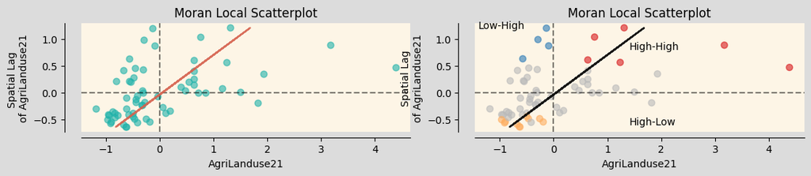

```python
fig, (ax0,ax1) = plt.subplots(1,2,figsize=(11, 10))


moran_scatterplot(moran_loc, ax=ax0)
ax0.set_xlabel('AgriLanduse21')
ax0.set_ylabel('Spatial Lag \nof AgriLanduse21')
ax0.collections[0].set_color('lightseagreen')
ax0.set_facecolor('oldlace')


moran_scatterplot(moran_loc, p=0.05, ax=ax1)
ax1.set_xlabel('AgriLanduse21')
ax1.set_ylabel('Spatial Lag\nof AgriLanduse21')
ax1.set_facecolor('oldlace')

ax1.annotate('High-High', xy=(1.4,0.8))
ax1.annotate('High-Low', xy=(1.4,-0.6))
ax1.annotate('Low-High', xy=(-1.4,1.2))

fig.set_facecolor('gainsboro')
plt.tight_layout()
plt.show()
```

## 🗺️ LISA Cluster Map helper function

**Objective:** Visualize spatial clusters using Local Moran's I.

```python
from splot.esda import lisa_cluster
```

```python
def plot_lisa_cluster(moran_loc = None, kmlfile = None,
                      p=0.05, fsize = (5,7),
                      title = 'Default title'):

    if (moran_loc == None):
        return
    if((kmlfile is None) or kmlfile.empty):
        return

    fig, ax = lisa_cluster(moran_loc, kmlfile, p=0.05, figsize = fsize)
    ax.set_title(title)

    # drop offshore island
    plt.xlim((101.5, 110))
    plt.ylim((8.2, 23.5))

    fig.set_facecolor('oldlace')
    plt.tight_layout()
    plt.show()
    return
```

## 🧪 Helper function: combining global and local

**Objective:** Pair LISA clusters with Moran scatterplots for full spatial diagnostics.

- Combines global scatterplots with local cluster mapping.
- Enhances interpretability of spatial patterns and regional anomalies.

```python
from splot.esda import plot_local_autocorrelation
```

```python
def plot_local_autocorr(moran_loc=None, kmlfile=None, title='Agri21', fsize=(10,4),
                        ax0_xlab = 'agriuse21', ax0_ylab = 'spatial lag',
                        ax1_title = 'LISA cluster', ax2_title='agriuse21'):

    if (moran_loc == None):
        return
    if((kmlfile is None) or kmlfile.empty):
        return

    fig,axs=plot_local_autocorrelation(moran_loc, kmlfile, title, figsize=fsize)

    axs[0].set_xlabel(ax0_xlab)
    axs[0].set_ylabel(ax0_ylab)
    axs[0].set_facecolor('oldlace')

    axs[1].set_title(ax1_title)
    axs[2].set_title(ax2_title)

    axs[1].set_facecolor('#81a0af')
    axs[1].set_xlim((101.5,110))
    axs[1].set_ylim((8.2,23.5))

    axs[2].set_facecolor('#81a0af')
    axs[2].set_xlim((101.5,110))
    axs[2].set_ylim((8.2,23.5))


    fig.set_facecolor('oldlace')
    plt.tight_layout()
    plt.show()

    return
```

## Spatial Autocorrelation on agricultural land use 2021 using Moran’s I(global clustering) and LISA

```
Ignoring fixed x limits to fulfill fixed data aspect with adjustable data limits.
Ignoring fixed x limits to fulfill fixed data aspect with adjustable data limits.
Ignoring fixed y limits to fulfill fixed data aspect with adjustable data limits.
Ignoring fixed y limits to fulfill fixed data aspect with adjustable data limits.
```

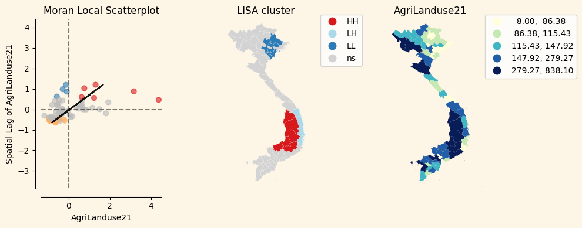

```python
plot_local_autocorr(moran_loc, kmlfile, 'Agri21', fsize=(10,4),
                    ax0_xlab='AgriLanduse21', ax0_ylab='Spatial Lag of AgriLanduse21',
                    ax1_title='LISA cluster', ax2_title='AgriLanduse21')
```

- LISA shows clustering at AU level,
  - HH: red hot spots
  - LL: blue cold spots
  - LH(Light blue): outliers — AUs with low agri land use surrounded by high-use neighbors
  - ns(grey): not statistically significant and no strong spatial pattern

# 🔄 Bivariate Spatial Relationships (Agri Land Use vs Other Factors)

## 💰 Land Use vs Income (2020)

**Objective:** Explore co-location of agriculture with income levels

```python
from esda.moran import Moran_BV, Moran_Local_BV
from splot.esda import plot_moran_bv_simulation, plot_moran_bv
```

```python
moran = Moran(kmlfile.Agri21,wmatrix)
moran_bv = Moran_BV(kmlfile.Agri21, kmlfile.incm_2020, wmatrix)
moran_loc = Moran_Local(kmlfile.Agri21, wmatrix)
moran_loc_bv = Moran_Local_BV(kmlfile.Agri21, kmlfile.incm_2020, wmatrix)
```

interpret bivariate scatterplot

[AM-23 - Local Measures of Spatial Association](https://gistbok.ucgis.org/bok-topics/local-measures-spatial-association#Bivariate)

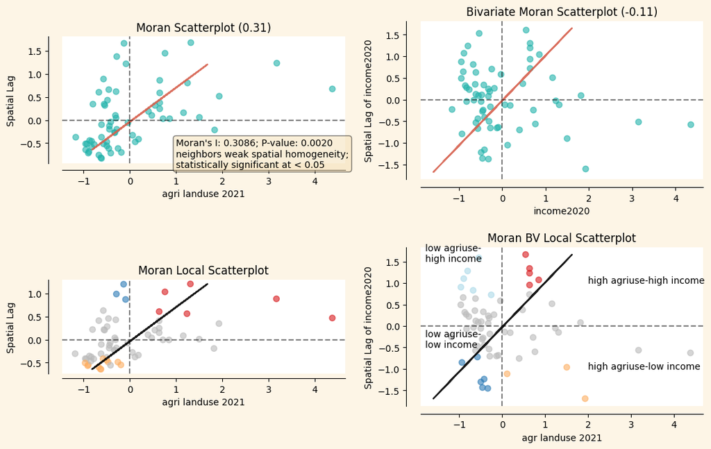

```python
fig, axs = plt.subplots(2, 2, figsize=(11,7),
                        subplot_kw={'aspect': 'equal'})

moran_scatterplot(moran, ax=axs[0,0])
axs[0,0].set_xlabel('agri landuse 2021')
axs[0,0].collections[0].set_color('lightseagreen')
axs[0,0].annotate(f"Moran's I: {moran.I:.4f}; P-value: {moran.p_sim:.4f}\n" \
            + "neighbors weak spatial homogeneity;\nstatistically significant at < 0.05"
            , xy=(1, -0.4)
            , ha='left', va='top', fontsize=10
            , bbox=dict(boxstyle='round', facecolor='wheat', alpha=0.5))

moran_scatterplot(moran_loc, p=0.05, ax=axs[1,0])
axs[1,0].set_xlabel('agri landuse 2021')

moran_scatterplot(moran_bv, ax=axs[0,1])
axs[0,1].set_xlabel('income2020')
axs[0,1].set_ylabel('Spatial Lag of income2020')
axs[0,1].collections[0].set_color('lightseagreen')

moran_scatterplot(moran_loc_bv, p=0.05, ax=axs[1,1])
axs[1,1].set_xlabel('agr landuse 2021')
axs[1,1].set_ylabel('Spatial Lag of income2020')
axs[1,1].annotate('high agriuse-high income', xy=(2,1))
axs[1,1].annotate('high agriuse-low income', xy=(2,-1))
axs[1,1].annotate('low agriuse-\nlow income', xy=(-1.8,-0.5))
axs[1,1].annotate('low agriuse-\nhigh income', xy=(-1.8,1.5))

fig.set_facecolor('oldlace')
plt.tight_layout()
plt.show()
```

interpret **Bivariate moran(agri use and income)**

- -0.11: no correlation or very weak dissimilarity
- local scatterplot with LISA
  - High agri use - high income ▶ south - mekong, makes sense \
  - High agri use - low income ▶ northwest mountainous areas \
  - Low agri use - high income ▶ Hanoi, Ho Chih Min - capital cities, makes sense \
  - Low agri use - low income ▶ northern admin units: coincides with poorest?

```
Ignoring fixed x limits to fulfill fixed data aspect with adjustable data limits.
Ignoring fixed x limits to fulfill fixed data aspect with adjustable data limits.
Ignoring fixed y limits to fulfill fixed data aspect with adjustable data limits.
Ignoring fixed y limits to fulfill fixed data aspect with adjustable data limits.
```

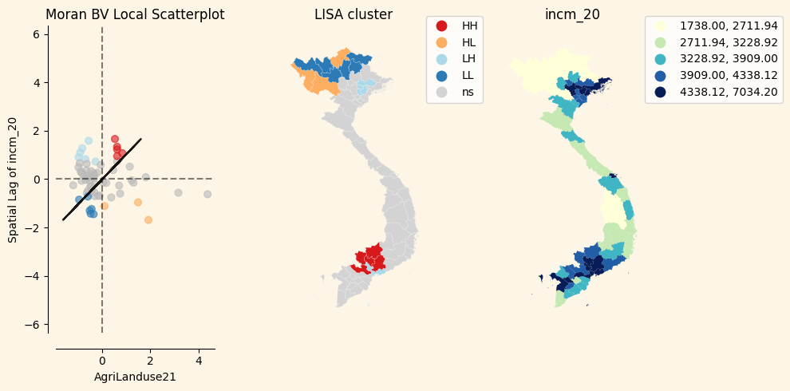

```python
plot_local_autocorr(moran_loc_bv, kmlfile, title='incm_2020', fsize=(10,5),
                    ax0_xlab='AgriLanduse21', ax0_ylab='Spatial Lag of incm_20',
                    ax1_title='LISA cluster', ax2_title='incm_20')
```

## 👥 Bivariate Land use vs **Total Avg** Population

**Objective:** Examine how land use aligns with population clusters.

```python
from esda.moran import Moran_BV, Moran_Local_BV
from splot.esda import plot_moran_bv_simulation, plot_moran_bv
```

```python
moran = Moran(kmlfile.Agri21,wmatrix)
moran_bv = Moran_BV(kmlfile.Agri21, kmlfile.TotAvgPop_20, wmatrix)
moran_loc = Moran_Local(kmlfile.Agri21, wmatrix)
moran_loc_bv = Moran_Local_BV(kmlfile.Agri21, kmlfile.TotAvgPop_20, wmatrix)
```

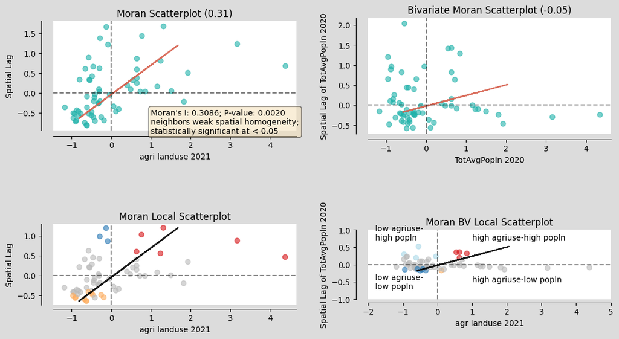

```python
fig, axs = plt.subplots(2, 2, figsize=(11,7),
                        subplot_kw={'aspect': 'equal'})

moran_scatterplot(moran, ax=axs[0,0])
axs[0,0].set_xlabel('agri landuse 2021')
axs[0,0].collections[0].set_color('lightseagreen')
axs[0,0].annotate(f"Moran's I: {moran.I:.4f}; P-value: {moran.p_sim:.4f}\n" \
            + "neighbors weak spatial homogeneity;\nstatistically significant at < 0.05"
            , xy=(1, -0.4)
            , ha='left', va='top', fontsize=10
            , bbox=dict(boxstyle='round', facecolor='wheat', alpha=0.5))

moran_scatterplot(moran_loc, p=0.05, ax=axs[1,0])
axs[1,0].set_xlabel('agri landuse 2021')

moran_scatterplot(moran_bv, ax=axs[0,1])
axs[0,1].set_xlabel('TotAvgPopln 2020')
axs[0,1].set_ylabel('Spatial Lag of TotAvgPopln 2020')
axs[0,1].collections[0].set_color('lightseagreen')

moran_scatterplot(moran_loc_bv, p=0.05, ax=axs[1,1])
axs[1,1].set_xlim(-2,5)
axs[1,1].set_ylim(-1,1)
axs[1,1].set_xlabel('agr landuse 2021')
axs[1,1].set_ylabel('Spatial Lag of TotAvgPopln 2020')
axs[1,1].annotate('high agriuse-high popln', xy=(1,.7))
axs[1,1].annotate('high agriuse-low popln', xy=(1,-.5))
axs[1,1].annotate('low agriuse-\nlow popln', xy=(-1.8,-0.7))
axs[1,1].annotate('low agriuse-\nhigh popln', xy=(-1.8,.7))

fig.set_facecolor('gainsboro')
plt.tight_layout()
plt.show()
```

interpret **Bivariate moran(agri use and tot avg popln)**

```
Ignoring fixed x limits to fulfill fixed data aspect with adjustable data limits.
Ignoring fixed x limits to fulfill fixed data aspect with adjustable data limits.
Ignoring fixed y limits to fulfill fixed data aspect with adjustable data limits.
Ignoring fixed y limits to fulfill fixed data aspect with adjustable data limits.
```

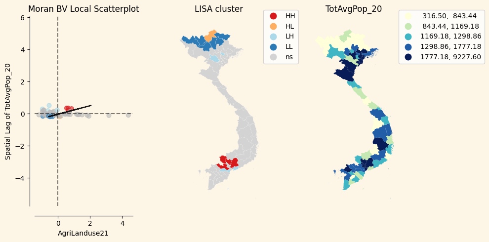

```python
plot_local_autocorr(moran_loc_bv, kmlfile, title='TotAvgPop_20', fsize=(10,5),
                    ax0_xlab='AgriLanduse21', ax0_ylab='Spatial Lag of TotAvgPop_20',
                    ax1_title='LISA cluster', ax2_title='TotAvgPop_20')
```

**Bivariate Moran's I(agriculture land use vs population) and LISA**

- [red Hot spots] High agriculture land area, high population
  - occured in the south
  - corresponds to the known `rice bowl` mekong delta
- [orange] High agriculture land area, low population
  - northern tip of country
  - surrounded by a low agriculture land use and low population band
  - basis to investigate since northern areas are mountainous and disadvantageous to agriculture
  - potentially the [One Commune, One Product(OCOP)](https://openknowledge.fao.org/server/api/core/bitstreams/e5db9abd-059b-4f9d-8b9d-130d101d8a94/content) has yield results in [Ha Giang agriculture sector goes far with OCOP products](https://vietnamagriculture.nongnghiep.vn/ha-giang-agriculture-sector-goes-far-with-ocop-products-d322183.html)
- [light blue] Low agriculture land area, high population
  - Seen at fringes of Hanoi in the Red River Delta
  - Supports the idea of urban expansion beyond the capital
- [dark blue] Low agriculture land area, low population
  - Mostly in northern provinces where forestry dominates
  - Matches expectations for sparsely populated, mountainous zones

***corrobrating with population information***

[figure not shown]

**corroborate with population density**

[figure not shown]

## 🌾 Bivariate Land use vs **Rural** Population

**Objective:** Investigate agricultural use alignment with rural population density.

```python
moran = Moran(kmlfile.Agri21,wmatrix)
moran_bv = Moran_BV(kmlfile.Agri21, kmlfile.RuralPop_20, wmatrix)
moran_loc = Moran_Local(kmlfile.Agri21, wmatrix)
moran_loc_bv = Moran_Local_BV(kmlfile.Agri21, kmlfile.RuralPop_20, wmatrix)
```

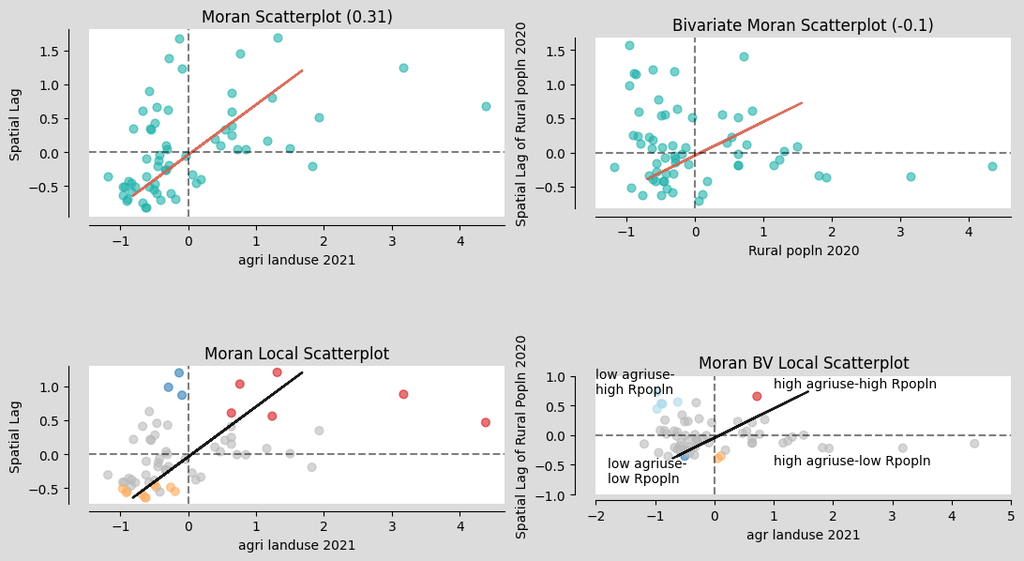

```python
fig, axs = plt.subplots(2, 2, figsize=(11,7),
                        subplot_kw={'aspect': 'equal'})

moran_scatterplot(moran, ax=axs[0,0])
axs[0,0].set_xlabel('agri landuse 2021')
axs[0,0].collections[0].set_color('lightseagreen')

moran_scatterplot(moran_loc, p=0.05, ax=axs[1,0])
axs[1,0].set_xlabel('agri landuse 2021')

moran_scatterplot(moran_bv, ax=axs[0,1])
axs[0,1].collections[0].set_color('lightseagreen')
axs[0,1].set_xlabel('Rural popln 2020')
axs[0,1].set_ylabel('Spatial Lag of Rural popln 2020')

moran_scatterplot(moran_loc_bv, p=0.05, ax=axs[1,1])
axs[1,1].set_xlim(-2,5)
axs[1,1].set_ylim(-1,1)
axs[1,1].set_xlabel('agr landuse 2021')
axs[1,1].set_ylabel('Spatial Lag of Rural Popln 2020')
axs[1,1].annotate('high agriuse-high Rpopln', xy=(1,.8))
axs[1,1].annotate('high agriuse-low Rpopln', xy=(1,-.5))
axs[1,1].annotate('low agriuse-\nlow Rpopln', xy=(-1.8,-0.8))
axs[1,1].annotate('low agriuse-\nhigh Rpopln', xy=(-2,.7))

fig.set_facecolor('gainsboro')
plt.tight_layout()
plt.show()
```

interpret **Bivariate moran(agri use and rural popln)**

- -0.1: no correlation or very weak dissimilarity
- local scatterplot with LISA cluster
  - High agri use - high Rpopln ▶ midnorth - 🤔 area is more for forestry than agriculture
  - High agri use - low Rpopln ▶ probably to support Da Nang - makes sense \
  - Low agri use - high Rpopln ▶ near Ha Noi, most income from employment, indicates urbanized area \
  - Low agri use - low Rpopln ▶ northern mountainous admin units, looks reasonable

```
Ignoring fixed x limits to fulfill fixed data aspect with adjustable data limits.
Ignoring fixed x limits to fulfill fixed data aspect with adjustable data limits.
Ignoring fixed y limits to fulfill fixed data aspect with adjustable data limits.
Ignoring fixed y limits to fulfill fixed data aspect with adjustable data limits.
```

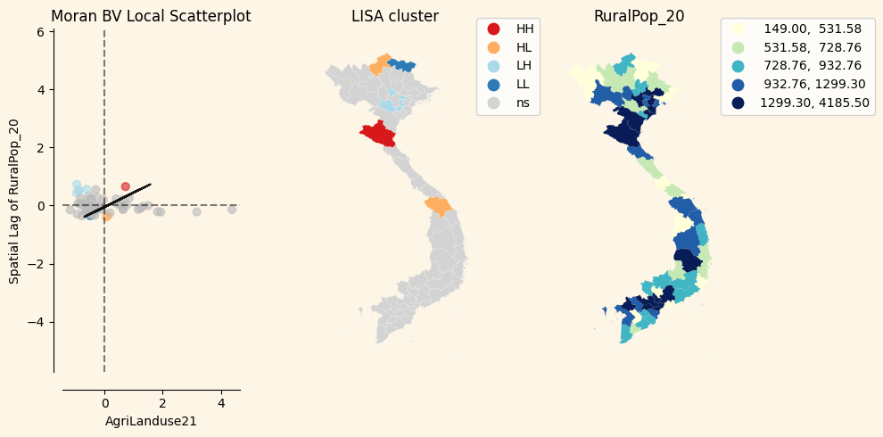

```python
plot_local_autocorr(moran_loc_bv, kmlfile, title='RuralPop_20', fsize=(10,5),
                    ax0_xlab='AgriLanduse21', ax0_ylab='Spatial Lag of RuralPop_20',
                    ax1_title='LISA cluster', ax2_title='RuralPop_20')
```

**corroborate with rural population information**

[figure not shown]

## 🏙️ Bivariate Land use vs **Urban** Population

**Objective:** Identify urban pressures on agricultural land.

```python
moran = Moran(kmlfile.Agri21,wmatrix)
moran_bv = Moran_BV(kmlfile.Agri21, kmlfile.UrbanPop_20, wmatrix)
moran_loc = Moran_Local(kmlfile.Agri21, wmatrix)
moran_loc_bv = Moran_Local_BV(kmlfile.Agri21, kmlfile.UrbanPop_20, wmatrix)
```

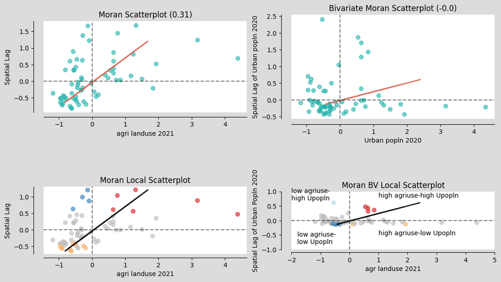

```python
fig, axs = plt.subplots(2, 2, figsize=(11,7),
                        subplot_kw={'aspect': 'equal'})

moran_scatterplot(moran, ax=axs[0,0])
axs[0,0].set_xlabel('agri landuse 2021')
axs[0,0].collections[0].set_color('lightseagreen')

moran_scatterplot(moran_loc, p=0.05, ax=axs[1,0])
axs[1,0].set_xlabel('agri landuse 2021')

moran_scatterplot(moran_bv, ax=axs[0,1])
axs[0,1].collections[0].set_color('lightseagreen')
axs[0,1].set_xlabel('Urban popln 2020')
axs[0,1].set_ylabel('Spatial Lag of Urban popln 2020')

moran_scatterplot(moran_loc_bv, p=0.05, ax=axs[1,1])
axs[1,1].set_xlim(-2,5)
axs[1,1].set_ylim(-1,1)
axs[1,1].set_xlabel('agr landuse 2021')
axs[1,1].set_ylabel('Spatial Lag of Urban Popln 2020')
axs[1,1].annotate('high agriuse-high Upopln', xy=(1,.8))
axs[1,1].annotate('high agriuse-low Upopln', xy=(1,-.5))
axs[1,1].annotate('low agriuse-\nlow Upopln', xy=(-1.8,-0.8))
axs[1,1].annotate('low agriuse-\nhigh Upopln', xy=(-2,.7))

fig.set_facecolor('gainsboro')
plt.tight_layout()
plt.show()
```

interpret **Bivariate moran(agri use and Urban popln)**

- 0.0: random
- local scatterplot with LISA cluster
  - High agri use - high Upopln ▶ south - hmm 🤔 \
  - High agri use - low Upopln ▶ northwest - compare with rural pop, and total pop, sparse pop area? \
  - Low agri use - high Upopln ▶ near HoChihMin, naturally \
  - Low agri use - low Upopln ▶ northern admin units: coincides with Urban pop too, poorest?

```
Ignoring fixed x limits to fulfill fixed data aspect with adjustable data limits.
Ignoring fixed x limits to fulfill fixed data aspect with adjustable data limits.
Ignoring fixed x limits to fulfill fixed data aspect with adjustable data limits.
Ignoring fixed x limits to fulfill fixed data aspect with adjustable data limits.
```

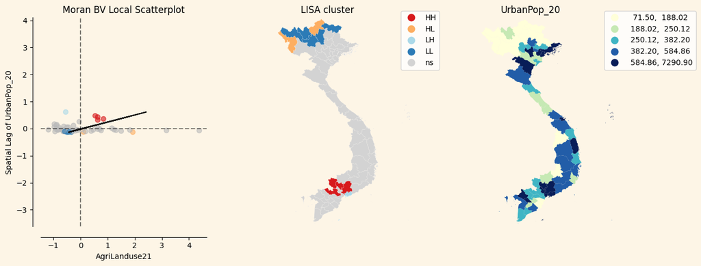

```python
plot_local_autocorr(moran_loc_bv, kmlfile, title='UrbanPop_20', fsize=(13,5),
                    ax0_xlab='AgriLanduse21', ax0_ylab='Spatial Lag of UrbanPop_20',
                    ax1_title='LISA cluster', ax2_title='UrbanPop_20')
```

**corroborating with urban population information**

[figure not shown]

## Bivariate Land use vs No. Enterprise

```python
kmlfile.columns
```

```
Index(['Name', 'description', 'timestamp', 'begin', 'end', 'altitudeMode',
       'tessellate', 'extrude', 'visibility', 'drawOrder', 'icon', 'Code',
       'TotalArea21', 'TotalArea16', 'TotalArea12', 'TotalPctChg', 'Agri21',
       'Agri16', 'Agri12', 'Fores21', 'Fores16', 'Fores12', 'Spec21', 'Spec16',
       'Spec12', 'Hmstd21', 'Hmstd16', 'Hmstd12', 'incmInfl_2012',
       'incmInfl_2016', 'incm_2020', 'TotAvgPop_20', 'TotAvgPop_16',
       'TotAvgPop_12', 'UrbanPop_20', 'UrbanPop_16', 'UrbanPop_12',
       'RuralPop_20', 'RuralPop_16', 'RuralPop_12', 'Province', 'Entpr_2012',
       'Entpr_2016', 'Entpr_2020', 'Emply_2020', 'Emply_2016', 'Emply_2012',
       'geometry'],
      dtype='object')
```

```python
moran = Moran(kmlfile.Agri21,wmatrix)
moran_bv = Moran_BV(kmlfile.Agri21, kmlfile.Entpr_2020, wmatrix)
moran_loc = Moran_Local(kmlfile.Agri21, wmatrix)
moran_loc_bv = Moran_Local_BV(kmlfile.Agri21, kmlfile.Entpr_2020, wmatrix)
```

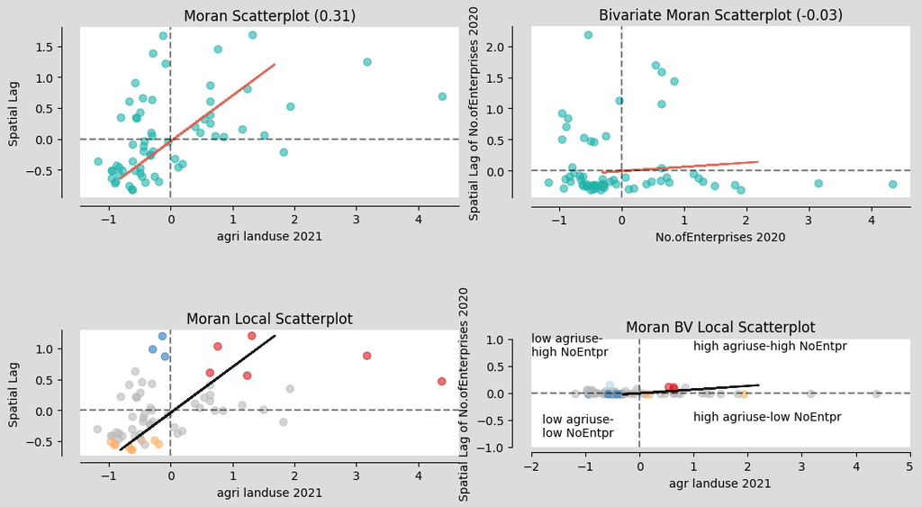

```python
fig, axs = plt.subplots(2, 2, figsize=(11,7),
                        subplot_kw={'aspect': 'equal'})

moran_scatterplot(moran, ax=axs[0,0])
axs[0,0].set_xlabel('agri landuse 2021')
axs[0,0].collections[0].set_color('lightseagreen')

moran_scatterplot(moran_loc, p=0.05, ax=axs[1,0])
axs[1,0].set_xlabel('agri landuse 2021')

moran_scatterplot(moran_bv, ax=axs[0,1])
axs[0,1].collections[0].set_color('lightseagreen')
axs[0,1].set_xlabel('No.ofEnterprises 2020')
axs[0,1].set_ylabel('Spatial Lag of No.ofEnterprises 2020')

moran_scatterplot(moran_loc_bv, p=0.05, ax=axs[1,1])
axs[1,1].set_xlim(-2,5)
axs[1,1].set_ylim(-1,1)
axs[1,1].set_xlabel('agr landuse 2021')
axs[1,1].set_ylabel('Spatial Lag of No.ofEnterprises 2020')
axs[1,1].annotate('high agriuse-high NoEntpr', xy=(1,.8))
axs[1,1].annotate('high agriuse-low NoEntpr', xy=(1,-.5))
axs[1,1].annotate('low agriuse-\nlow NoEntpr', xy=(-1.8,-0.8))
axs[1,1].annotate('low agriuse-\nhigh NoEntpr', xy=(-2,.7))

fig.set_facecolor('gainsboro')
plt.tight_layout()
plt.show()
```

interpret **Bivariate moran(agri use and no. enterprise)**

- -0.03: spatial randomness
- local scatterplot with LISA cluster
  - High agri use - high NoEntpr ▶ south - rice bowl region, hmm 🤔 what enterprises? \
  - High agri use - low NoEntpr ▶ northwest - compare with rural pop, and total pop, sparse pop area? \
  - Low agri use - high NoEntpr ▶ near HoChihMin, naturally \
  - Low agri use - low NoEntpr ▶ northern admin units: coincides with Urban pop too, poorest?

```
Ignoring fixed x limits to fulfill fixed data aspect with adjustable data limits.
Ignoring fixed x limits to fulfill fixed data aspect with adjustable data limits.
Ignoring fixed y limits to fulfill fixed data aspect with adjustable data limits.
Ignoring fixed y limits to fulfill fixed data aspect with adjustable data limits.
```

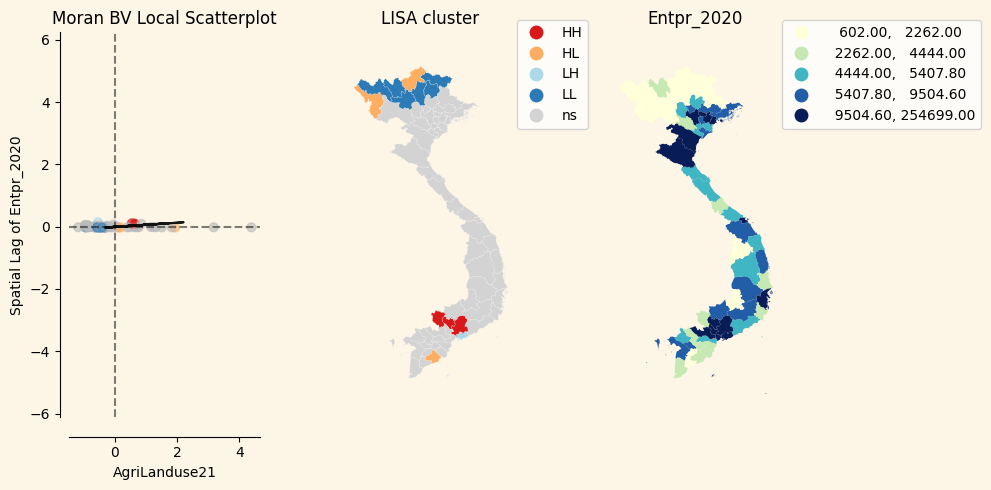

```python
plot_local_autocorr(moran_loc_bv, kmlfile, title='Entpr_2020', fsize=(10,5),
                    ax0_xlab='AgriLanduse21', ax0_ylab='Spatial Lag of Entpr_2020',
                    ax1_title='LISA cluster', ax2_title='Entpr_2020')
```

**corroborating with enterprise information**

[figure not shown]

## Bivariate Land use vs employment

```python
kmlfile.columns
```

```
Index(['Name', 'description', 'timestamp', 'begin', 'end', 'altitudeMode',
       'tessellate', 'extrude', 'visibility', 'drawOrder', 'icon', 'Code',
       'TotalArea21', 'TotalArea16', 'TotalArea12', 'TotalPctChg', 'Agri21',
       'Agri16', 'Agri12', 'Fores21', 'Fores16', 'Fores12', 'Spec21', 'Spec16',
       'Spec12', 'Hmstd21', 'Hmstd16', 'Hmstd12', 'incmInfl_2012',
       'incmInfl_2016', 'incm_2020', 'TotAvgPop_20', 'TotAvgPop_16',
       'TotAvgPop_12', 'UrbanPop_20', 'UrbanPop_16', 'UrbanPop_12',
       'RuralPop_20', 'RuralPop_16', 'RuralPop_12', 'Province', 'Entpr_2012',
       'Entpr_2016', 'Entpr_2020', 'Emply_2020', 'Emply_2016', 'Emply_2012',
       'geometry'],
      dtype='object')
```

```python
moran = Moran(kmlfile.Agri21,wmatrix)
moran_bv = Moran_BV(kmlfile.Agri21, kmlfile.Emply_2020, wmatrix)
moran_loc = Moran_Local(kmlfile.Agri21, wmatrix)
moran_loc_bv = Moran_Local_BV(kmlfile.Agri21, kmlfile.Emply_2020, wmatrix)
```

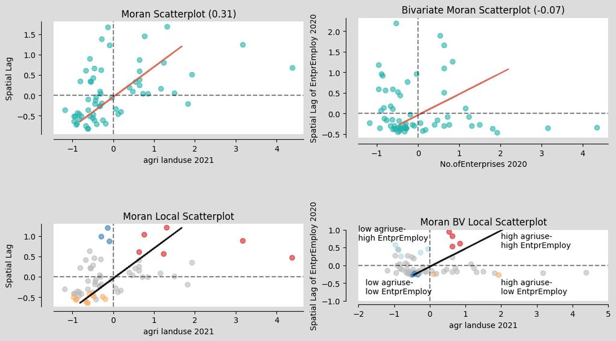

```python
fig, axs = plt.subplots(2, 2, figsize=(11,7),
                        subplot_kw={'aspect': 'equal'})

moran_scatterplot(moran, ax=axs[0,0])
axs[0,0].set_xlabel('agri landuse 2021')
axs[0,0].collections[0].set_color('lightseagreen')

moran_scatterplot(moran_loc, p=0.05, ax=axs[1,0])
axs[1,0].set_xlabel('agri landuse 2021')

moran_scatterplot(moran_bv, ax=axs[0,1])
axs[0,1].collections[0].set_color('lightseagreen')
axs[0,1].set_xlabel('No.ofEnterprises 2020')
axs[0,1].set_ylabel('Spatial Lag of EntprEmploy 2020')

moran_scatterplot(moran_loc_bv, p=0.05, ax=axs[1,1])
axs[1,1].set_xlim(-2,5)
axs[1,1].set_ylim(-1,1)
axs[1,1].set_xlabel('agr landuse 2021')
axs[1,1].set_ylabel('Spatial Lag of EntprEmploy 2020')
axs[1,1].annotate('high agriuse-\nhigh EntprEmploy', xy=(2,.5))
axs[1,1].annotate('high agriuse-\nlow EntprEmploy', xy=(2,-.8))
axs[1,1].annotate('low agriuse-\nlow EntprEmploy', xy=(-1.8,-0.8))
axs[1,1].annotate('low agriuse-\nhigh EntprEmploy', xy=(-2,.7))

fig.set_facecolor('gainsboro')
plt.tight_layout()
plt.show()
```

interpret **Bivariate moran(agri use and No. Employed by Enterprises)**

- -0.07: spatial randomness
- local scatterplot with LISA cluster
  - very minor difference with No.Enterprises near 2 capital cities(Ha Noi, HoChihMinh city) for Low agriuse and high employment

```
Ignoring fixed x limits to fulfill fixed data aspect with adjustable data limits.
Ignoring fixed x limits to fulfill fixed data aspect with adjustable data limits.
Ignoring fixed y limits to fulfill fixed data aspect with adjustable data limits.
Ignoring fixed y limits to fulfill fixed data aspect with adjustable data limits.
```

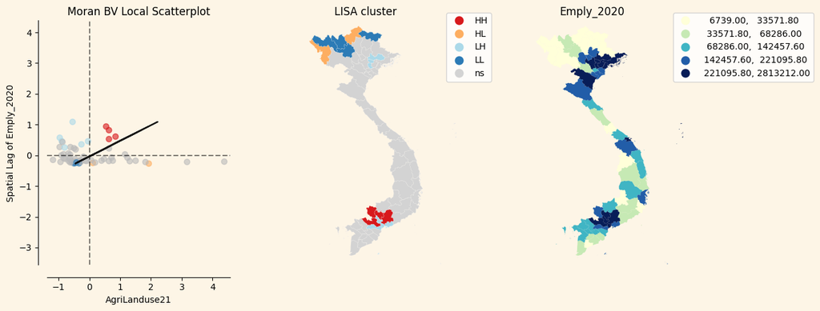

```python
plot_local_autocorr(moran_loc_bv, kmlfile, title='Emply_2020', fsize=(13,5),
                    ax0_xlab='AgriLanduse21', ax0_ylab='Spatial Lag of Emply_2020',
                    ax1_title='LISA cluster', ax2_title='Emply_2020')
```

**corroborating with (employment) hiring location**

[figure not shown]

**Temporal change in (employment)hiring**

[figure not shown]

# OTHER INFO

## Temporal change in farm population

*Vietnam underwent farm consolidation for resource optimization*

[figure not shown]

## Land allocation(%) to farm

*From land allocated(pie chart) by province(bars) to number of farms(stacked bars)*  
*reduced number of farms reflects consolidation though allocated agriculture land increased*

[figure not shown]

## Cultivation farms by Province

*Cultivation concentrated in southern provinces*

[figure not shown]

## land allocation to cultivation output

*translating land area to crop types and output*

[figure not shown]

## change in livestock farm count

*farms concentrated around most populous AUs, indicative of higher income(corroborated by income plot) and accessibility to animal protein*

[figure not shown]

## Total Household income by AU

*High income AUs concentrated around capital city, Ha Noi and Ho Chih Minh City. Income is likely derived from employment and high number of enterprises(corroborated by employment and enterprise count plots). Total monthly household income = Employment salary + Self-employment(AFF + Non-AFF) + Others*

*AFF: Agriculture, Forestry, Fishery*

[figure not shown]

## Household income spread by AU and Province

[figure not shown]

## Spread of total household income components by province

*poverty line indicative of food security amongst households*

[figure not shown]

## Temporal change in Total Income

*changes from 2010(green, baseline) to 2016 and 2020. coloration in choropleth indicates rapid rise from 2010 to 2016 and slowdown between 2016 to 2020. The Central highlands appear to be particularly affected by the slowdown*

[figure not shown]

**Temporal change in AFF Income**  
*2010(red, baseline) to 2016 and 2020. AFF income is on the decline, indicating Viet Nam's departure from AFF income.*

[figure not shown]

*end of file*